# RegressionPlots

Dr. B

Sunday, September 28, 2014

## Load required libraries

```
## The Commander GUI is launched only in interactive sessions
```

## Load Data

Load the mtcars dataset, attach the dataset, and review the variables.

```r
data(mtcars)
attach(mtcars)
str(mtcars)
```

[output not shown]

## OLS Regression

```r
gear <- factor(gear,levels=c(3,4,5),labels=c("3gears","4gears","5gears"))
cyl <- factor(cyl,levels=c(4,6,8),labels=c("4cyl","6cyl","8cyl"))
am <- factor(am,levels=c(0,1),labels=c("Automatic","Manual"))
#mtcars$vs <- factor(mtcars$vs)
#mtcars$carb <- factor(mtcars$carb)
```

Perform stepwise model selection in order to select significant predictors for the final, best model. The step function will perform this selection by calling lm repeatedly to build multiple regression models and select the best variables from them using both forward selection and backward elimination methods using AIC algorithm. This ensures that the useful variables are included in the model while omitting ones that do not contribute significantly to predicting mpg.

```r
bestmodel <- step(lm(mpg ~ ., data = mtcars), direction = "both")
summary(bestmodel)
```

[output not shown]

## Plain Scatterplots

Simple Scatterplot

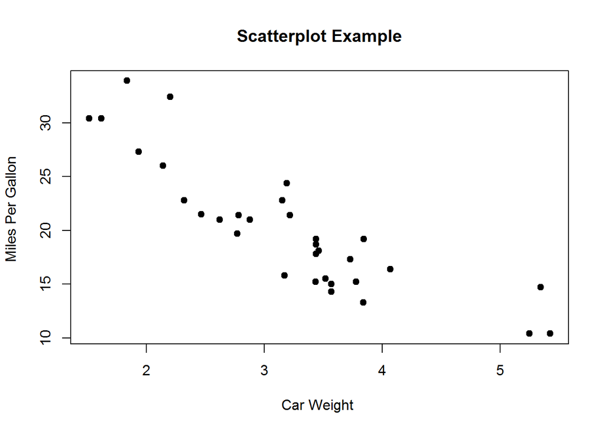

Add fit lines

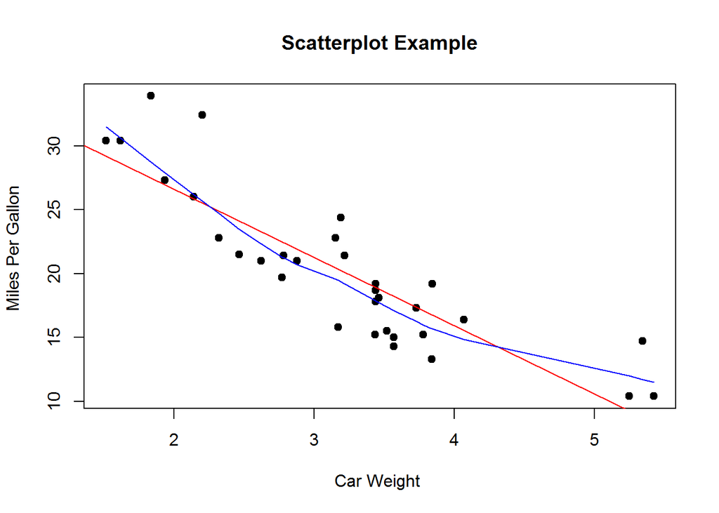

Enhanced features, including fit lines, marginal box plots, conditioning on a factor, and interactive point identification. Each of these features is optional.

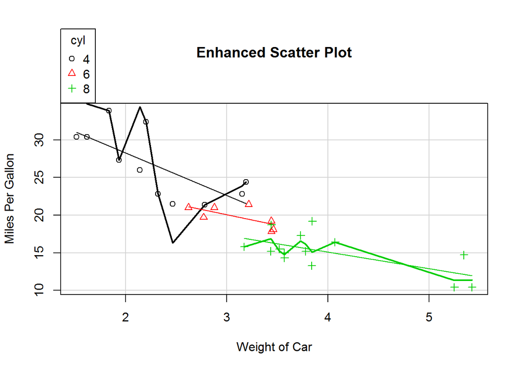

## 3D Scatterplots

Plain 3D Scatterplot

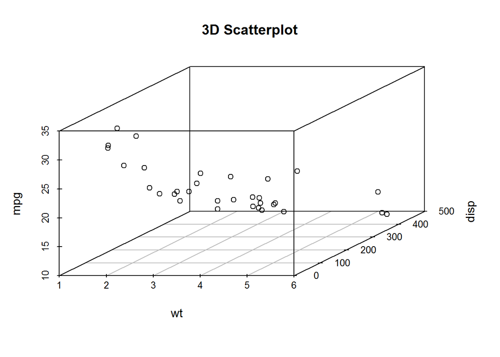

3D Scatterplot with Coloring and Vertical Drop Lines

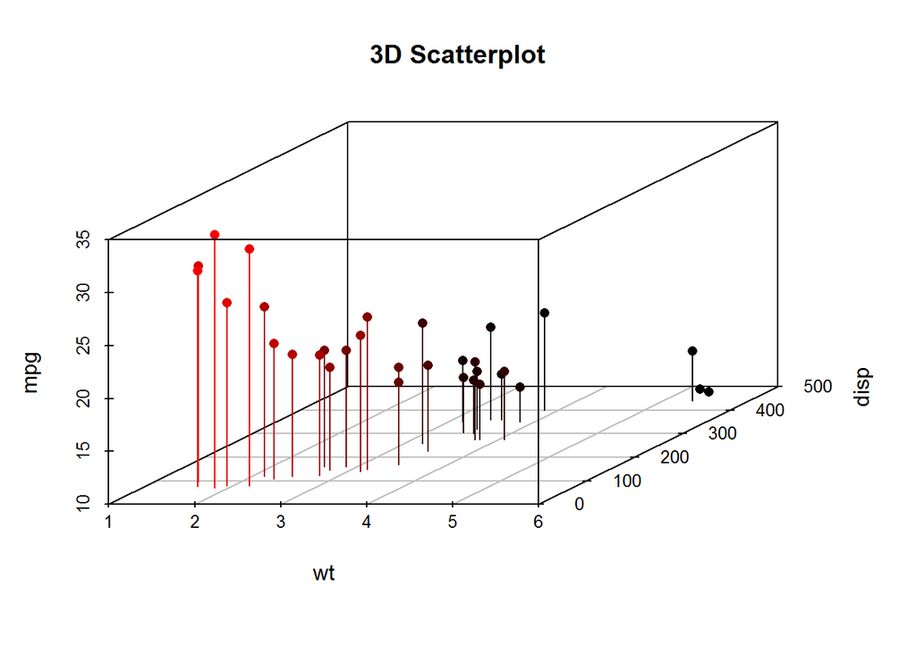

3D Scatterplot with Coloring and Vertical Lines and Regression Plane

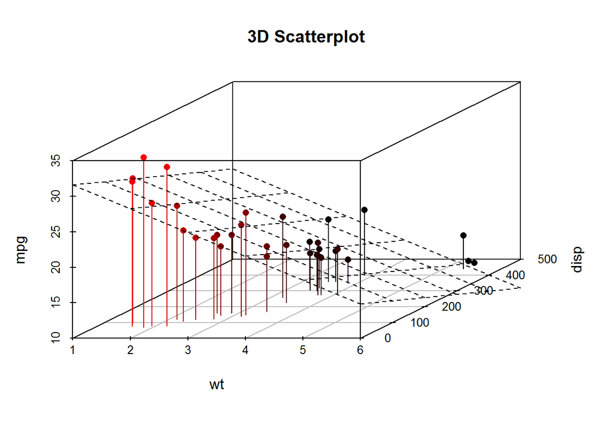

## High Density Scatterplots

High Density Scatterplot with Binning

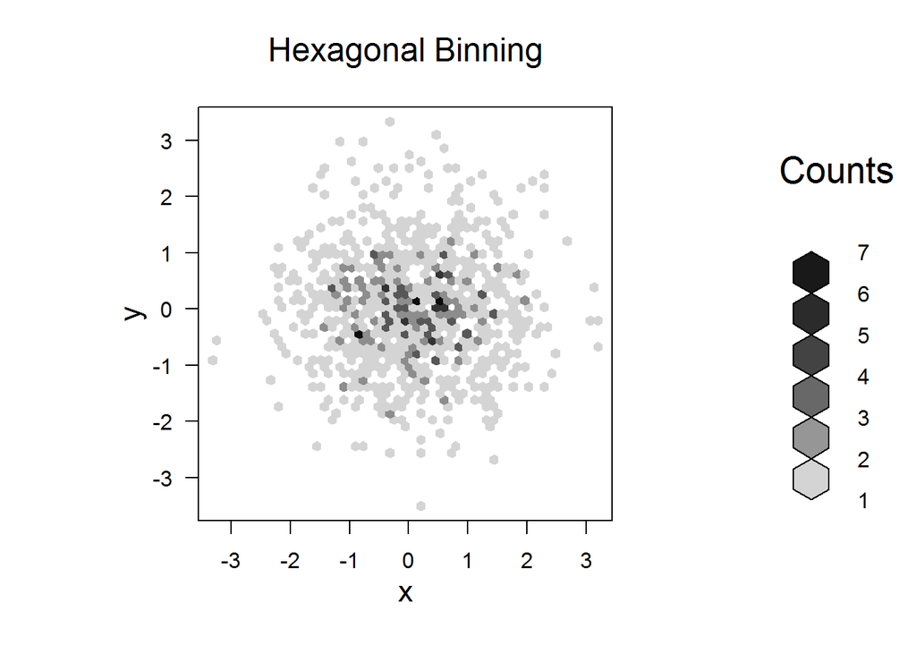

## Basic Scatterplot Matrices

Basic Scatterplot Matrix

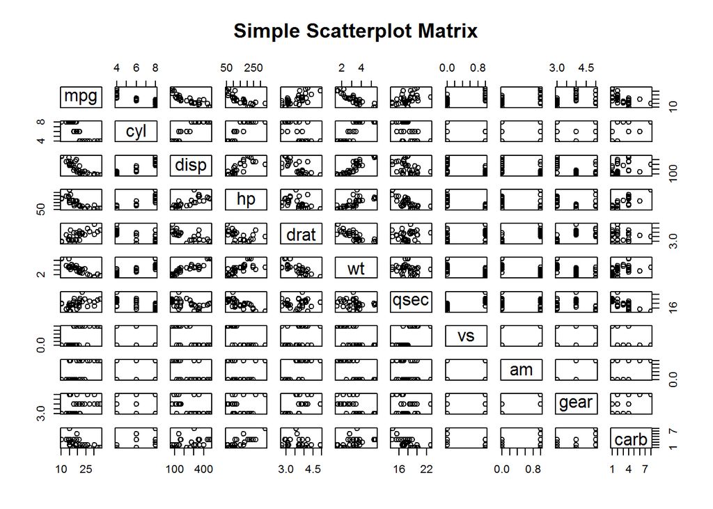

Condition the scatterplot matrix on a factor.

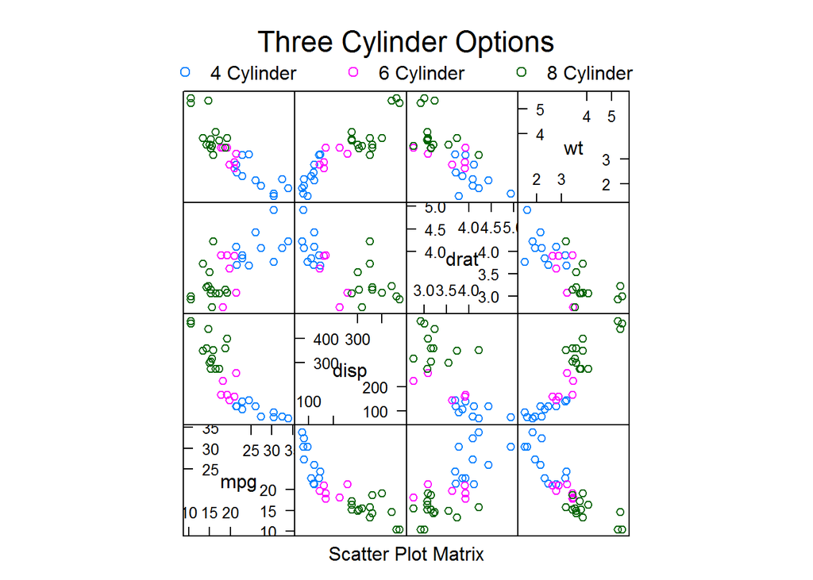

Condition the scatterplot matrix on a factor, and optionally include lowess and linear best fit lines, and boxplot, densities, or histograms in the principal diagonal, as well as rug plots in the margins of the cells.

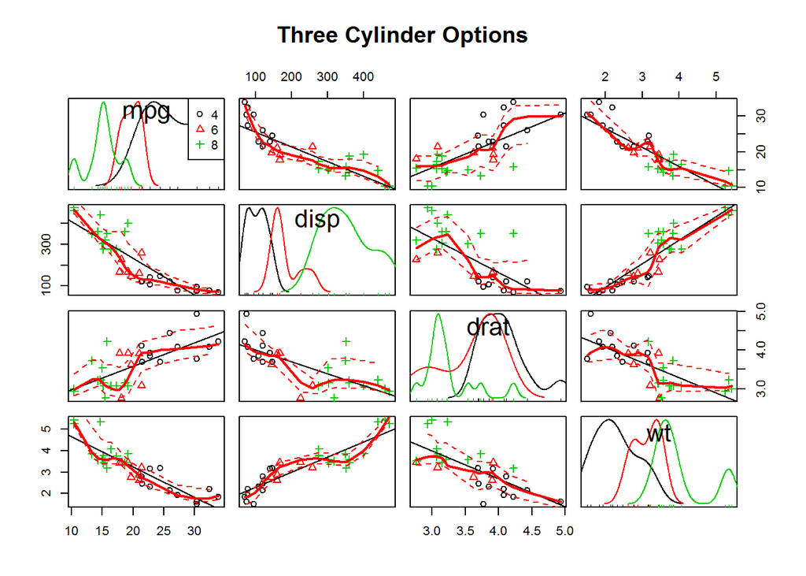

Options to rearrange the variables so that those with higher correlations are closer to the principal diagonal. Color code the cells to reflect the size of the correlations.

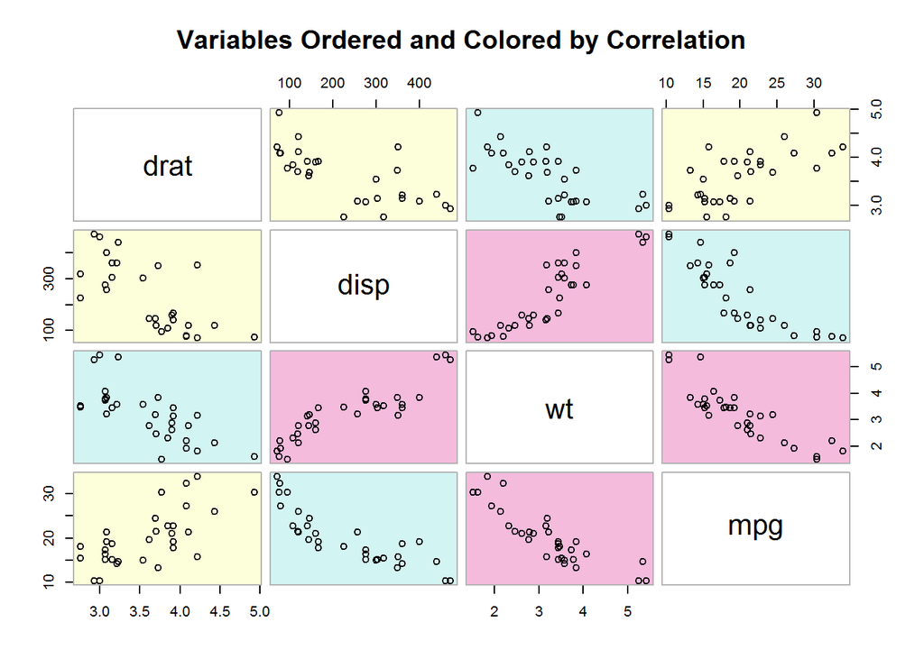

Spinning 3D Scatterplots